# CS579: Assignment 1

## Collecting a political social network

In this assignment, I've given you a list of Twitter accounts of 10 U.S. Senators. The goal is to use the Twitter API to construct the follower network of these accounts. We will then use the [networkx](http://networkx.github.io/) library to plot these links, as well as print some statistics of the resulting graph.

1. Follow the instructions in Readme.md to configure your system.
2. Copy the files from this directory into the `asg/a1` folder of your private repository.
3. Create an account on twitter.com.
4. Generate authentication tokens by following the instructions [here](https://dev.twitter.com/docs/auth/tokens-devtwittercom).
5. Add your tokens to the `twitter.cfg` file. (API Key == Consumer Key)
6. Be sure you've installed the Python modules [networkx](http://networkx.github.io/) and TwitterAPI. Assuming you've already installed [pip](http://pip.readthedocs.org/en/latest/installing.html), you can do this with `pip install networkx TwitterAPI`.

OK, now you're ready to start collecting some data!

I've provided a partial implementation below. Your job is to complete the code where indicated. Your output should match the samples provided below.

```python
import ConfigParser
import sys
import time

import matplotlib.pyplot as plt
import networkx as nx
from TwitterAPI import TwitterAPI

# This method is done for you.
def get_twitter(config_file):
    """ Read the config_file and construct an instance of TwitterAPI.
    Args:
      config_file ... A config file in ConfigParser format with Twitter credentials
    Returns:
      An instance of TwitterAPI.
    """
    config = ConfigParser.ConfigParser()
    config.read(config_file)
    twitter = TwitterAPI(
                   config.get('twitter', 'consumer_key'),
                   config.get('twitter', 'consumer_secret'),
                   config.get('twitter', 'access_token'),
                   config.get('twitter', 'access_token_secret'))
    return twitter

twitter = get_twitter('twitter.cfg')
print 'Established Twitter connection.'
```

```
Established Twitter connection.
```

```python
def read_senators(filename):
    """ Read a list of usernames for U.S. senators.
    Args:
      filename: The name of the text file containing one senator username per file.
    Returns:
      A list of usernames
    """
    # Complete this method.
    return None

senators = read_senators('senators.txt')
print 'Read', len(senators), 'senators:\n', '\n'.join(senators)
```

```
Read 10 senators:
MarkUdall
SenGillibrand
SenatorLeahy
PattyMurray
SenJohnMcCain
McConnellPress
DavidVitter
SenatorHagan
kaybaileyhutch
SenatorCarper
```

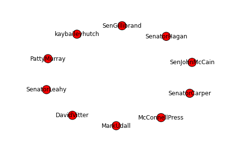

```python
# Add senators as nodes.
def create_graph(senators):
    """ Create a networkx DiGraph, adding each senator as a node.
    Args:
      senators: a list of Senator Twitter screen names.
    Returns:
      A networkx DiGraph
    """
    # Complete this method.
    return None

graph = create_graph(senators)
nx.draw(graph)
plt.savefig("senators.png")
```

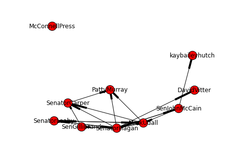

```python
# Now query the Twitter API to add directed edges between all senators X and Y if X follows Y.

# I've provided the method below to handle Twitter's rate limiting.
def robust_request(twitter, resource, params, max_tries=5):
    """ If a Twitter request fails, sleep for 15 minutes.
    Do this at most max_tries times before quitting.
    Args:
      twitter .... A TwitterAPI object.
      resource ... A resource string to request.
      params ..... A parameter dictionary for the request.
      max_tries .. The maximum number of tries to attempt.
    Returns:
      A TwitterResponse object, or None if failed.
    """
    for i in range(max_tries):
        request = twitter.request(resource, params)
        if request.status_code == 200:
            return request
        else:
            print >> sys.stderr, 'Got error:', request.text, '\nsleeping for 15 minutes.'
            sys.stderr.flush()
            time.sleep(60 * 15)


def get_friends(screen_name, twitter):
    """ Return Twitter screen names for all accounts followed by screen_name. Returns the first 200 users.
    See docs at: https://dev.twitter.com/docs/api/1.1/get/friends/list
    Args:
      screen_name ... The query account.
      twitter ....... The TwitterAPI object.
    Returns:
      A list of Twitter screen names.
    """
    # Complete this method.
    return None

def add_edges(senators, graph, twitter):
    """ Add edges to the graph representing Senator X following Senator Y.
    For each senator, call the get_friends method to get the list of other people s/he follows.
    Then, for each friend that is on the original senator list, add an edge to the graph.

    Args:
      senators ... A list of senator screen names.
      graph ...... A networkx graph.
      twitter .... TwitterAPI object.
    """
    # Complete this method.
    return None


add_edges(senators, graph, twitter)
# Draw the new graph and save to file.
# Note that your graph may differ somewhat based on the results of what Twitter returns.
nx.draw(graph)
plt.savefig("senators-edges.png")
```

```
degree
('DavidVitter', 1)
('MarkUdall', 7)
('McConnellPress', 0)
('PattyMurray', 3)
('SenGillibrand', 3)
('SenJohnMcCain', 4)
('SenatorCarper', 4)
('SenatorHagan', 11)
('SenatorLeahy', 4)
('kaybaileyhutch', 1)

betweenness
('DavidVitter', 0.0)
('MarkUdall', 0.034722222222222224)
('McConnellPress', 0.0)
('PattyMurray', 0.0)
('SenGillibrand', 0.0)
('SenJohnMcCain', 0.05555555555555555)
('SenatorCarper', 0.006944444444444444)
('SenatorHagan', 0.25)
('SenatorLeahy', 0.0)
('kaybaileyhutch', 0.0)
```

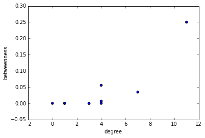

```python
# Now print and plot the degree and betweenness_centrality of each node.
# See the networkx functions `degree` and `betweenness_centrality` at
# http://networkx.github.io/documentation.html
def get_degrees(graph):
    """
    Args:
      graph ... A networkx graph
    Returns:
      Return a list of (senator, degree) tuples.
    """
    # Complete this method.
    return None

def get_betweenness_centrality(graph):
    """
    Args:
      graph ... A networkx graph
    Returns:
      Return a list of (senator, degree) tuples.
    """
    # Complete this method.
    return None

# No need to modify the code below.
degrees = get_degrees(graph)
betweens = get_betweenness_centrality(graph)
print 'degree'
print '\n'.join([str(d) for d in degrees])
print '\nbetweenness'
print '\n'.join([str(b) for b in betweens])
plt.scatter([d[1] for d in degrees], [b[1] for b in betweens])
plt.xlabel('degree')
plt.ylabel('betweenness')
plt.savefig('degree.png')
```

That's it for now! This should give you a simple introduction to some of the key issues we'll cover in this course.